# Milestone Report

Anatoly Andrianov

7/11/2020

## Introduction

The goal of this *Milestone Report* is to satisfy the requirements of the [week 2 assignment](https://www.coursera.org/learn/data-science-project/peer/BRX21/milestone-report) by demonstrating that I’ve gotten used to working with the project data set and that I’m “on track” to create my prediction algorithm.

## Obtaining data

The data for this project has been downloaded from [Capstone Dataset](https://d396qusza40orc.cloudfront.net/dsscapstone/dataset/Coursera-SwiftKey.zip).

For simplicity I’m not including code used for file download and un-ZIPping.

The downloaded data set (3 text files in `en_US` locale) have been stored in the directory structure following the original archive. The files are very large. The following code illustrates their size in MB:

```r
# file sizes
dataset.properties <- data.frame(row.names = c("blogs", "news", "twitter"),
                                 fileSize = c(file.info("data/final/en_US/en_US.blogs.txt")$size/1024^2,
                                              file.info("data/final/en_US/en_US.news.txt")$size/1024^2,
                                              file.info("data/final/en_US/en_US.twitter.txt")$size/1024^2))
dataset.properties
```

|  | fileSize |
| --- | --- |
| blogs | 200.4242 |
| news | 196.2775 |
| twitter | 159.3641 |

## Loading data

The text data has been loaded into character vectors using the readLines command. The encoding has been set to `UTF-8` and `NULL` lines have been ignored. The code below illustrates the data loading process and resulting line counts.

```r
# first load blogs data
# open file for reading
blogs.file <- file("data/final/en_US/en_US.blogs.txt", "r")
# read the content while ignoring the NULLs
blogs.lines <- readLines(blogs.file, encoding = "UTF-8", skipNul = TRUE, warn = FALSE)
# close file
close(blogs.file)
# get rid of un-used variable
rm(blogs.file)

#next load news data
# open file for reading
news.file <- file("data/final/en_US/en_US.news.txt", "r")
# read the content while ignoring the NULLs
news.lines <- readLines(news.file, encoding = "UTF-8", skipNul = TRUE, warn = FALSE)
# close file
close(news.file)
# get rid of un-used variable
rm(news.file)

# finally load twitter data
# open file for reading
twitter.file <- file("data/final/en_US/en_US.twitter.txt", "r")
# read the content while ignoring the NULLs
twitter.lines <- readLines(twitter.file, encoding = "UTF-8", skipNul = TRUE, warn = FALSE)
# close file
close(twitter.file)
# get rid of un-used variable
rm(twitter.file)

# line counts
dataset.properties <- cbind(dataset.properties,
                            lineCount = c(length(blogs.lines),
                                          length(news.lines),
                                          length(twitter.lines)))
dataset.properties
```

|  | fileSize | lineCount |
| --- | --- | --- |
| blogs | 200.4242 | 899288 |
| news | 196.2775 | 77259 |
| twitter | 159.3641 | 2360148 |

## Major data features

The character vectors have been briefly analyzed using the `stringi` [package](https://www.rdocumentation.org/packages/stringi/) by Marek Gagolewski.

The table below summarizes the data set properties such as word counts (per data set and per line), character counts (per data set and per line).

```r
# load string processing library by Marek Gagolewski
library(stringi)
# data set properties
# word counts
dataset.properties <- cbind(dataset.properties,
                            wordCount = c(sum(stri_count_words(blogs.lines)),
                                          sum(stri_count_words(news.lines)),
                                          sum(stri_count_words(twitter.lines))))
# character counts
dataset.properties <- cbind(dataset.properties,
                            charCount = c(sum(nchar(blogs.lines)),
                                          sum(nchar(news.lines)),
                                          sum(nchar(twitter.lines))))
# averages
dataset.properties <- cbind(dataset.properties,
                            avgWords = c(mean(stri_count_words(blogs.lines)),
                                         mean(stri_count_words(news.lines)),
                                         mean(stri_count_words(twitter.lines))))
dataset.properties <- cbind(dataset.properties,
                            avgChars = c(mean(nchar(blogs.lines)),
                                         mean(nchar(news.lines)),
                                         mean(nchar(twitter.lines))))
dataset.properties
```

|  | fileSize | lineCount | wordCount | charCount | avgWords | avgChars |
| --- | --- | --- | --- | --- | --- | --- |
| blogs | 200.4242 | 899288 | 37546239 | 206824505 | 41.75107 | 229.98695 |
| news | 196.2775 | 77259 | 2674536 | 15639408 | 34.61779 | 202.42830 |
| twitter | 159.3641 | 2360148 | 30093413 | 162096241 | 12.75065 | 68.68054 |

### Data sampling

Because the complete data set is very large, we will continue our experimentation on a smaller sample of 10000 lines per data type. The resulting sample will be biased due to inconsistent sample size to file size ratio, but at this stage it’s not important.

```r
# set a random seed to ensure repeatability of the results
set.seed(1234)
# take a random sample of data (10,000 lines per source)
sample.lines <- c(sample(blogs.lines, 10000),
                  sample(news.lines, 10000),
                  sample(twitter.lines, 10000))
# free-up the memory
rm(blogs.lines)
rm(news.lines)
rm(twitter.lines)
gc()
```

```
##           used (Mb) gc trigger  (Mb) max used  (Mb)
## Ncells  535260 28.6    5643898 301.5  4241222 226.6
## Vcells 3692114 28.2   61399056 468.5 70751268 539.8
```

```r
# clean-up non-ASCII characters
sample.lines <- iconv(sample.lines, to = "ASCII", sub = "")
# get rid of http/ftp/etc...
sample.lines <- gsub("(f|ht)tp(s?)://(.*)[.][a-z]+", "", sample.lines)
# get rid of @...
sample.lines <- gsub("@[^\\s]+", "", sample.lines)
```

## Basic mining and clean-up

We will perform basic text mining and data clean-up using the `tm` [package](https://www.rdocumentation.org/packages/tm) and `RWeka` [package](https://www.rdocumentation.org/packages/RWeka).

We will create a corpus and clean it up (convert to lower case, strip white spaces/numbers/punctuation, and remove English stop words). The resulting clean corpus we will tokenize into uni-grams, by-grams, tri-grams and quad-grams. Finally we will show the frequency distributions for each type.

```r
library(tm)
# create corpus
corpus <- VCorpus(VectorSource(sample.lines))
# clean the corpus
corpus <- tm_map(corpus, tolower)
corpus <- tm_map(corpus, stripWhitespace)
corpus <- tm_map(corpus, removeNumbers)
corpus <- tm_map(corpus, removePunctuation)
corpus <- tm_map(corpus, removeWords, stopwords("english"))
corpus <- tm_map(corpus, PlainTextDocument)
# tokenize
library(RWeka)
# define tokenizer helper functions
uniTokenizer <- function(x) NGramTokenizer(x, Weka_control(min = 1, max = 1))
biTokenizer <- function(x) NGramTokenizer(x, Weka_control(min = 2, max = 2))
triTokenizer <- function(x) NGramTokenizer(x, Weka_control(min = 3, max = 3))
quadTokenizer <- function(x) NGramTokenizer(x, Weka_control(min = 4, max = 4))
# tokenize
unigrams <- TermDocumentMatrix(corpus, control = list(tokenize = uniTokenizer))
bigrams <- TermDocumentMatrix(corpus, control = list(tokenize = biTokenizer))
trigrams <- TermDocumentMatrix(corpus, control = list(tokenize = triTokenizer))
quadgrams <- TermDocumentMatrix(corpus, control = list(tokenize = quadTokenizer))

# get frequencies with low threshold of 100 to control the object size
helper <- sort(rowSums(as.matrix(unigrams[findFreqTerms(unigrams, lowfreq = 100),])), decreasing = TRUE)
uniFreqs <- data.frame(unigram=names(helper), frequency = helper)
helper <- sort(rowSums(as.matrix(bigrams[findFreqTerms(bigrams, lowfreq = 100),])), decreasing = TRUE)
biFreqs <- data.frame(bigram=names(helper), frequency = helper)
helper <- sort(rowSums(as.matrix(trigrams[findFreqTerms(trigrams, lowfreq = 10),])), decreasing = TRUE)
triFreqs <- data.frame(trigram=names(helper), frequency = helper)
helper <- sort(rowSums(as.matrix(quadgrams[findFreqTerms(quadgrams, lowfreq = 2),])), decreasing = TRUE)
quadFreqs <- data.frame(quadgram=names(helper), frequency = helper)
rm(helper)
```

### Top uni-grams

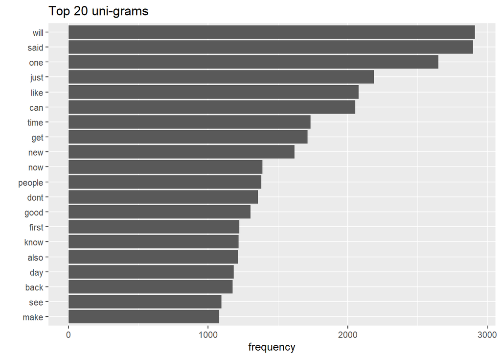

```r
library(ggplot2)
ggplot(uniFreqs[1:20,], aes(x = reorder(unigram, frequency), y = frequency)) +
    geom_bar(stat = "identity") +
    coord_flip() +
    labs(title = "Top 20 uni-grams") +
    xlab("")
```

### Top bi-grams

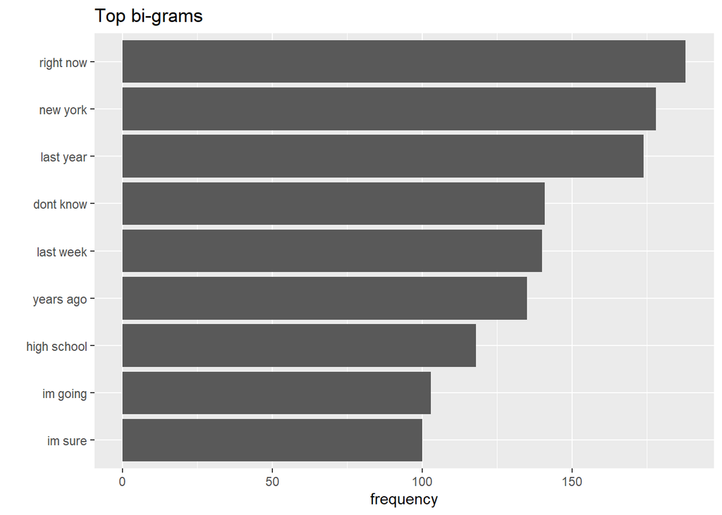

```r
ggplot(biFreqs, aes(x = reorder(bigram, frequency), y = frequency)) +
    geom_bar(stat = "identity") +
    coord_flip() +
    labs(title = "Top bi-grams") +
    xlab("")
```

### Top tri-grams

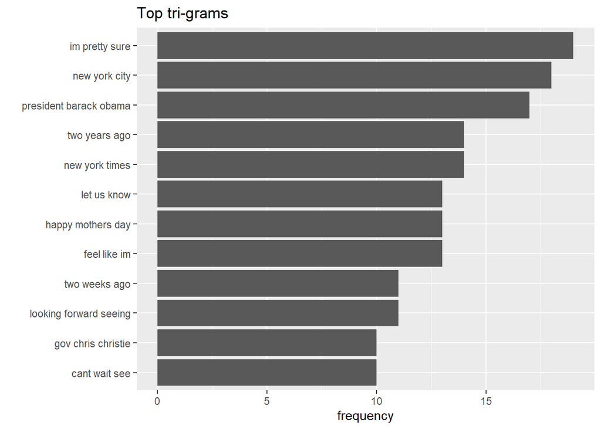

```r
ggplot(triFreqs, aes(x = reorder(trigram, frequency), y = frequency)) +
    geom_bar(stat = "identity") +
    coord_flip() +
    labs(title = "Top tri-grams") +
    xlab("")
```